Where do babies come from? Well, dinosaur babies come from eggs. Spoilers.

The discovery of dinosaur eggs involves some controversy, having been attributed to the wrong paleontologists twice. In 1923, American paleontologist George Olsen claimed to have found the first dinosaur egg shells in the Gobi Desert of Mongolia on an expedition led by Roy Andrews. News of the brown striated (ridged) shells he found was quickly publicized, with one paleontologist declaring in the French magazine L’Illustration that no one knew dinosaurs laid eggs prior to the discovery. This statement soon drew a response from the French paleontologist Louis Joleaud, who claimed that dinosaur egg shells had been found as early as 1869 in Marseille, France by the French paleontologist Philippe Matheron. The egg shells had been discovered in sedimentary rock containing dinosaur bones, likely having been inside the dinosaur when it died. Yet, this attribution to Matheron as the discoverer of dinosaur eggs was false as well!

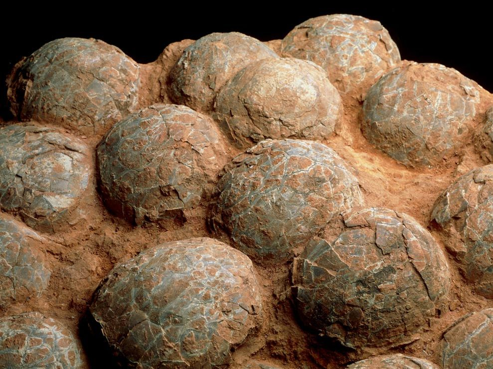

*Who discovered dinosaur eggs first?*

In 1859, the priest and geologist Jean-Jacques Pouech was exploring the French Pyrenees when he stumbled upon “eggshell fragments of very great dimensions” that he estimated were “at least four times the volume of ostrich eggs” with a radius of about 18 centimeters. Yet, Pouech did not believe the egg shells belonged to dinosaurs, but possibly “gigantic birds” or armadillos. Considering that the term “dinosaur” was coined 18 years earlier in 1841 and had yet to spread, Pouech may not have been familiar with the creatures of his discovery. Pouech did not make much of the egg shells other than their large size, and his papers were lost to history until 1986. Three years later, Pouech’s collection of fossil vertebrates was discovered at a college located in Pamiers, France. Among the preserved remains were the egg shells Pouech had described. Thus, for 60 years people had the wrong impression of how far back the discovery of dinosaur eggs went.